# rjags_weight_summary

Frizzles7

1/11/2021

## Problem Description

We will look at the following example problem to investigate the RJAGS package.

Prior studies have shown that weight is linearly related to height. Can we use height to make predictions regarding weight?

We will sample 10,000 draws from each of the priors and store these in a dataframe and view plots of these samples.

```r
library(rjags)
library(dplyr)
```

```r
library(ggplot2)

# Sample 10000 draws from each prior
a <- rnorm(10000, 0, 200)
b <- rnorm(10000, 1, 0.5)
s <- runif(10000, 0, 20)

# Store these samples in a dataframe
samples <- data.frame(set = 1:10000, a, b, s)

# View the head of this dataframe
head(samples)
```

```
##   set          a         b         s
## 1   1 -272.17232 0.8484980 15.552827
## 2   2  283.20753 0.6803357  8.191640
## 3   3  139.61046 1.8307157  1.209809
## 4   4  202.78257 0.6383436  3.936911
## 5   5  256.90963 1.6823975  5.314424
## 6   6   23.88115 0.6996546 19.504778
```

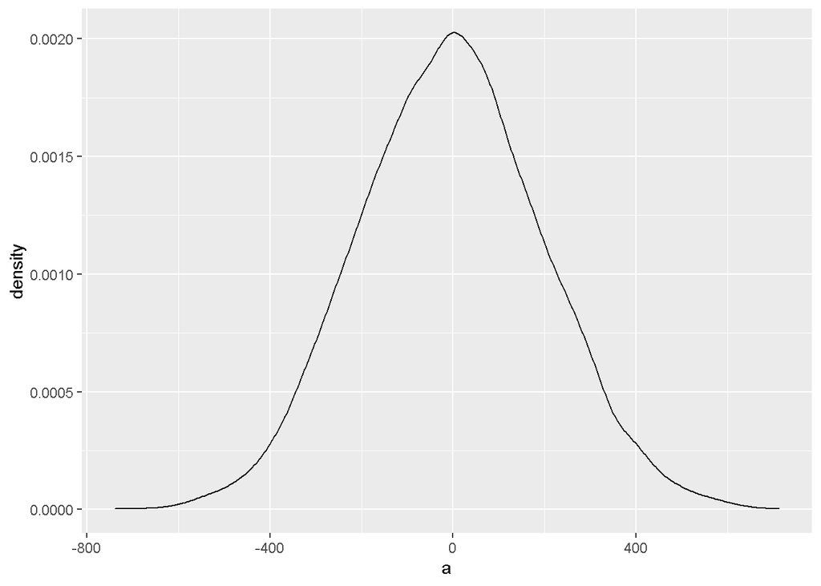

```r
# Construct density plots of the prior samples
ggplot(samples, aes(x = a)) + geom_density()
```

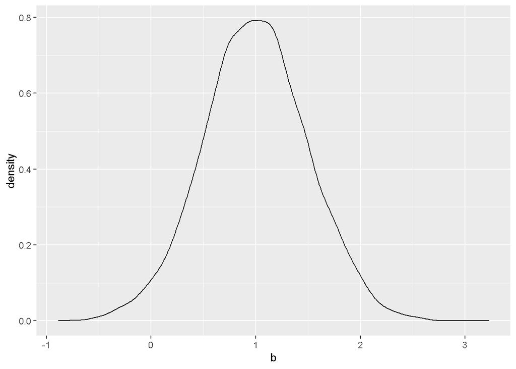

```r
ggplot(samples, aes(x = b)) + geom_density()
```

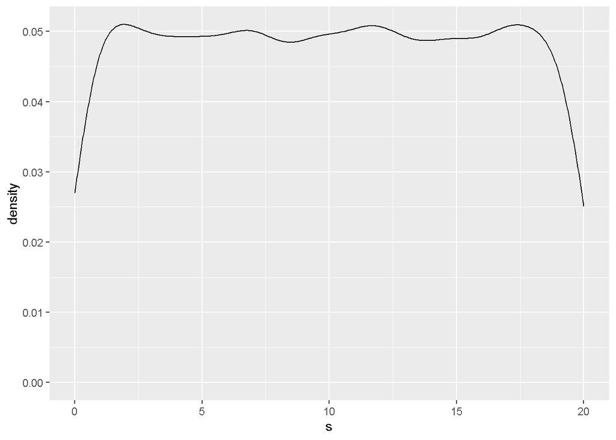

```r
ggplot(samples, aes(x = s)) + geom_density()
```

## Height and Weight Data

We can use physical measurements on height and weight for 507 individuals from the `bdims` dataset in the `openintro` package. This data can help us to build insights into the relationship between height and weight.

In this dataset, weight in kilograms is recorded in `wgt` and height in centimeters is recorded in `hgt`.

We can look at the relationship between height and weight in this data.

```r
library(openintro)
# View a summary of the bdims data
summary(bdims)
```

```
##      bia_di          bii_di          bit_di          che_de
##  Min.   :32.40   Min.   :18.70   Min.   :24.70   Min.   :14.30
##  1st Qu.:36.20   1st Qu.:26.50   1st Qu.:30.60   1st Qu.:17.30
##  Median :38.70   Median :28.00   Median :32.00   Median :19.00
##  Mean   :38.81   Mean   :27.83   Mean   :31.98   Mean   :19.23
##  3rd Qu.:41.15   3rd Qu.:29.25   3rd Qu.:33.35   3rd Qu.:20.90
##  Max.   :47.40   Max.   :34.70   Max.   :38.00   Max.   :27.50
##      che_di          elb_di          wri_di          kne_di
##  Min.   :22.20   Min.   : 9.90   Min.   : 8.10   Min.   :15.70
##  1st Qu.:25.65   1st Qu.:12.40   1st Qu.: 9.80   1st Qu.:17.90
##  Median :27.80   Median :13.30   Median :10.50   Median :18.70
##  Mean   :27.97   Mean   :13.39   Mean   :10.54   Mean   :18.81
##  3rd Qu.:29.95   3rd Qu.:14.40   3rd Qu.:11.20   3rd Qu.:19.60
##  Max.   :35.60   Max.   :16.70   Max.   :13.30   Max.   :24.30
##      ank_di          sho_gi           che_gi           wai_gi
##  Min.   : 9.90   Min.   : 85.90   Min.   : 72.60   Min.   : 57.90
##  1st Qu.:13.00   1st Qu.: 99.45   1st Qu.: 85.30   1st Qu.: 68.00
##  Median :13.80   Median :108.20   Median : 91.60   Median : 75.80
##  Mean   :13.86   Mean   :108.20   Mean   : 93.33   Mean   : 76.98
##  3rd Qu.:14.80   3rd Qu.:116.55   3rd Qu.:101.15   3rd Qu.: 84.50
##  Max.   :17.20   Max.   :134.80   Max.   :118.70   Max.   :113.20
##      nav_gi           hip_gi           thi_gi          bic_gi
##  Min.   : 64.00   Min.   : 78.80   Min.   :46.30   Min.   :22.40
##  1st Qu.: 78.85   1st Qu.: 92.00   1st Qu.:53.70   1st Qu.:27.60
##  Median : 84.60   Median : 96.00   Median :56.30   Median :31.00
##  Mean   : 85.65   Mean   : 96.68   Mean   :56.86   Mean   :31.17
##  3rd Qu.: 91.60   3rd Qu.:101.00   3rd Qu.:59.50   3rd Qu.:34.45
##  Max.   :121.10   Max.   :128.30   Max.   :75.70   Max.   :42.40
##      for_gi          kne_gi          cal_gi          ank_gi          wri_gi
##  Min.   :19.60   Min.   :29.00   Min.   :28.40   Min.   :16.40   Min.   :13.0
##  1st Qu.:23.60   1st Qu.:34.40   1st Qu.:34.10   1st Qu.:21.00   1st Qu.:15.0
##  Median :25.80   Median :36.00   Median :36.00   Median :22.00   Median :16.1
##  Mean   :25.94   Mean   :36.20   Mean   :36.08   Mean   :22.16   Mean   :16.1
##  3rd Qu.:28.40   3rd Qu.:37.95   3rd Qu.:38.00   3rd Qu.:23.30   3rd Qu.:17.1
##  Max.   :32.50   Max.   :49.00   Max.   :47.70   Max.   :29.30   Max.   :19.6
##       age             wgt              hgt             sex
##  Min.   :18.00   Min.   : 42.00   Min.   :147.2   Min.   :0.0000
##  1st Qu.:23.00   1st Qu.: 58.40   1st Qu.:163.8   1st Qu.:0.0000
##  Median :27.00   Median : 68.20   Median :170.3   Median :0.0000
##  Mean   :30.18   Mean   : 69.15   Mean   :171.1   Mean   :0.4872
##  3rd Qu.:36.00   3rd Qu.: 78.85   3rd Qu.:177.8   3rd Qu.:1.0000
##  Max.   :67.00   Max.   :116.40   Max.   :198.1   Max.   :1.0000
```

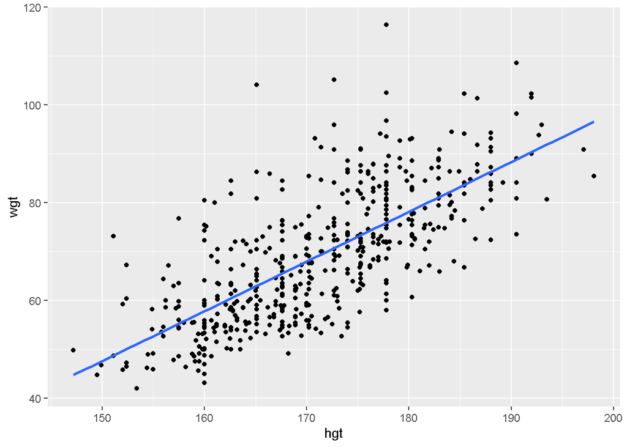

```r
# Create a scatterplot of height and weight, and include a visualization of the linear relationship
ggplot(bdims, aes(x = hgt, y = wgt)) + geom_point() + geom_smooth(method = "lm", se = FALSE)
```

## Define, Compile, and Simulate the Model

Using the priors from above and the observed data from the `bdims` dataset, we can update the posterior model of this relationship.

Priors: - $a \sim N(0, 200^2)$ - $b \sim N(1, 0.5^2)$ - $s \sim Uniform(0, 20)$

Likelihood: - $Y_i \sim N(m_i, s^2)$ where $m_i = a + b * X_i$

```r
# Define the model, including the likelihood and prior models
weight_model <- "model{
    # Likelihood model for Y[i]
    for(i in 1:length(Y)) {
        Y[i] ~ dnorm(m[i], s^(-2))
        m[i] <- a + b * X[i]
    }

    # Prior models for a, b, s
    a ~ dnorm(0, 200^(-2))
    b ~ dnorm(1, 0.5^(-2))
    s ~ dunif(0, 20)

}"

# Compile the model
weight_jags <- jags.model(
    textConnection(weight_model),
    data = list(Y = bdims$wgt, X = bdims$hgt),
    inits = list(.RNG.name = "base::Wichmann-Hill", .RNG.seed = 17)
)
```

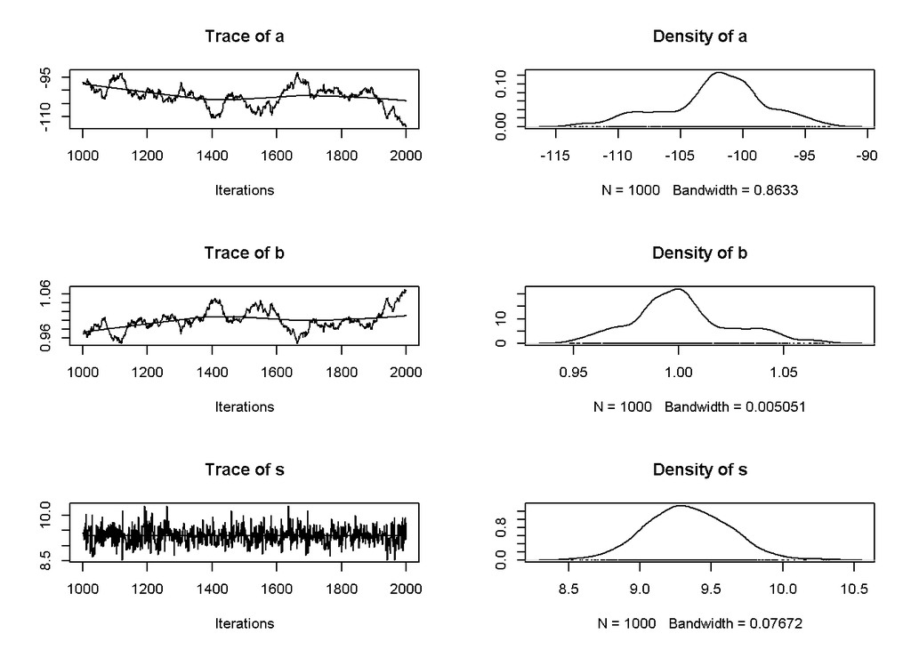

```r
# Simulate a sample from the posterior
weight_sim <- coda.samples(
    model = weight_jags,
    variable.names = c("a", "b", "s"),
    n.iter = 1000
)

# Plot the posterior sample
plot(weight_sim)
```

## Multiple Chains

To evaluate the quality of a Markov chain simulation, we should look at the stability as the length of the chain increases and the consistency across multiple chains. Let us review the trace plots for four parallel chains for our model.

```r
# Compile the model with multiple chains
weight_jags_multi <- jags.model(
    textConnection(weight_model),
    data = list(Y = bdims$wgt, X = bdims$hgt),
    n.chains = 4
)
```

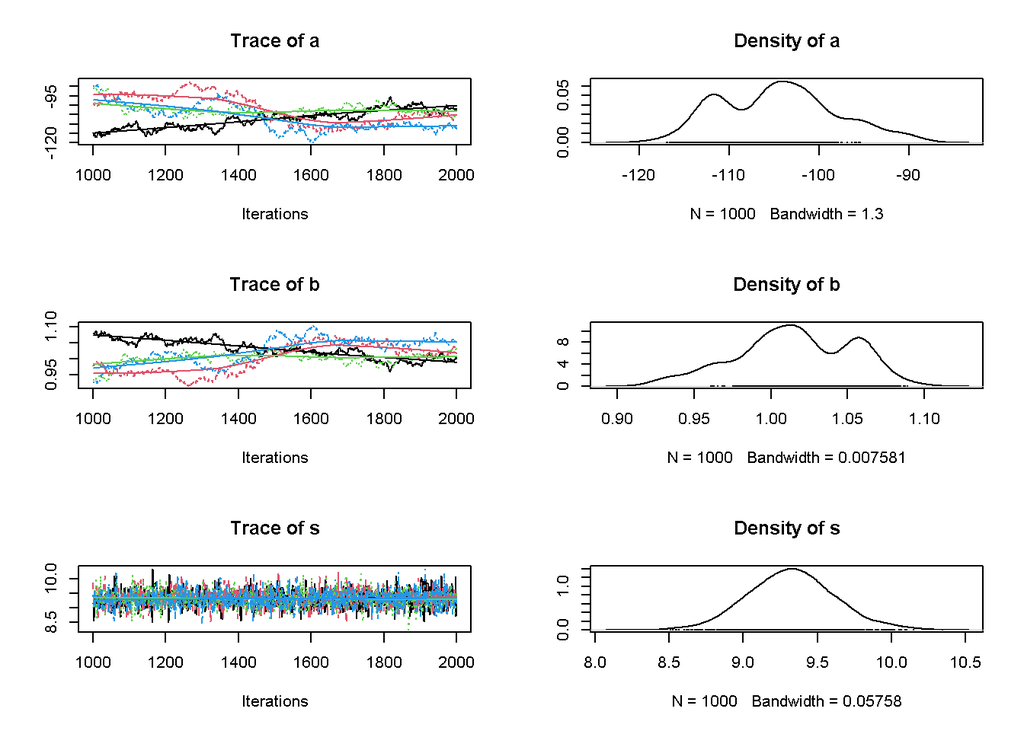

```r
# Simulate the sample from the posterior
weight_sim_multi <- coda.samples(
    model = weight_jags_multi,
    variable.names = c("a", "b", "s"),
    n.iter = 1000
)

# Plot the trace plots and densities for the parallel chains
plot(weight_sim_multi)
```

## Longer Chains

Upon reviewing the trace plots for the parallel chains, it appears that these chains are too short. They have not yet stabilized, so they are unlikely to provide a reliable approximation for the posterior.

We can create a new simulation with more iterations to provide a more reliable approximation for the posterior.

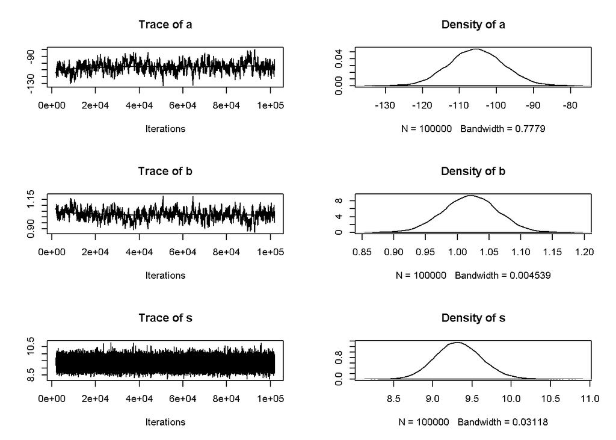

```r
# Simulate a longer chain by increasing the number of iterations
weight_sim_long <- coda.samples(
    model = weight_jags,
    variable.names = c("a", "b", "s"),
    n.iter = 100000
)

# Plot this longer chain
plot(weight_sim_long)
```

## Point Estimates

Using the longer chain, let us look at the posterior means. We can verify that the summary provides the mean of the posterior values from the chain.

We can also review the mean posterior regression model relative to several of the individual posterior regression models to note the variability.

```r
# Store the chains in a dataframe
weight_chains_long <- data.frame(weight_sim_long[[1]], iter = 1:100000)

# Review the head of this dataframe
head(weight_chains_long)
```

```
##           a        b        s iter
## 1 -112.9908 1.063346 9.730646    1
## 2 -113.7648 1.068119 9.631675    2
## 3 -113.8473 1.067175 9.657773    3
## 4 -113.6368 1.069310 9.636325    4
## 5 -114.4460 1.074970 9.204933    5
## 6 -114.4554 1.074614 9.362281    6
```

```r
# Review the summary of the simulation
summary(weight_sim_long)
```

```
##
## Iterations = 2001:102000
## Thinning interval = 1
## Number of chains = 1
## Sample size per chain = 1e+05
##
## 1. Empirical mean and standard deviation for each variable,
##    plus standard error of the mean:
##
##      Mean      SD  Naive SE Time-series SE
## a -105.48 7.33910 0.0232083       0.581221
## b    1.02 0.04282 0.0001354       0.003378
## s    9.33 0.29413 0.0009301       0.001217
##
## 2. Quantiles for each variable:
##
##        2.5%       25%      50%      75%   97.5%
## a -119.6738 -110.4200 -105.553 -100.579 -91.103
## b    0.9363    0.9918    1.021    1.049   1.103
## s    8.7743    9.1285    9.322    9.524   9.928
```

```r
# Calculate the posterior mean from the dataframe and verify this matches
mean(weight_chains_long$b)
```

```
## [1] 1.020374
```

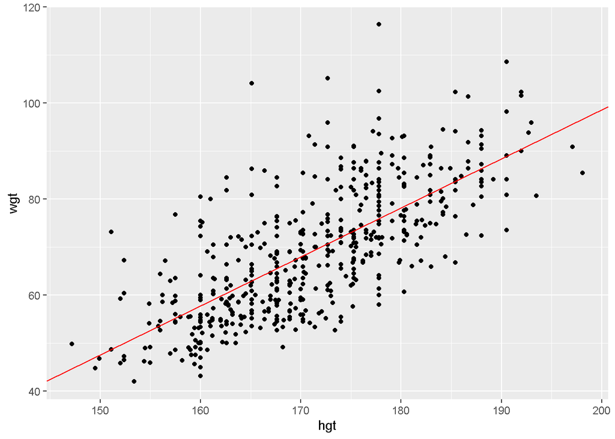

```r
# Plot the bdims data with the mean regression model
ggplot(bdims, aes(x = hgt, y = wgt)) +
    geom_point() +
    geom_abline(intercept = mean(weight_chains_long$a),
                slope = mean(weight_chains_long$b), color = "red")
```

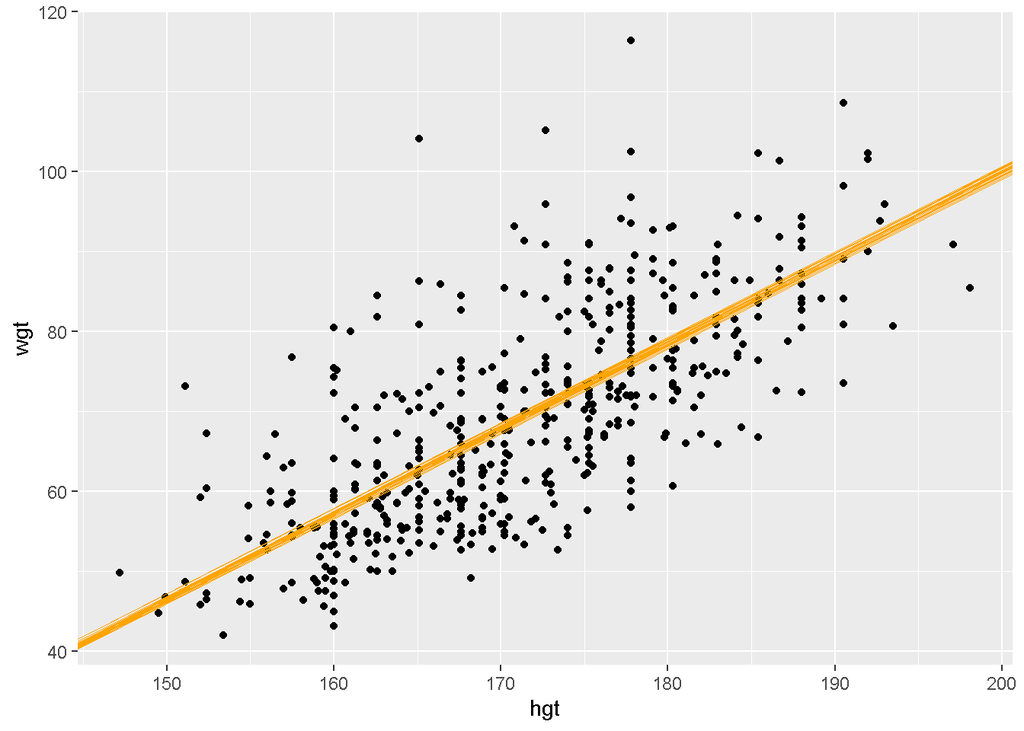

```r
# Compare to a plot of the first 20 posterior regression models
ggplot(bdims, aes(x = hgt, y = wgt)) +
    geom_point() +
    geom_abline(intercept = weight_chains_long$a[1:20],
                slope = weight_chains_long$b[1:20], color = "orange", size = 0.25)
```

## Posterior Credible Intervals

Now that we have looked at the posterior mean, let us look at a credible interval for b. That is, what is the plausible range of posterior slope values. We can calculate a 95% credible interval for b.

```r
# Calculate the 95% credible interval for b
ci_b_95 <- quantile(weight_chains_long$b, probs = c(0.025, 0.975))
ci_b_95
```

```
##     2.5%    97.5%
## 0.936252 1.103122
```

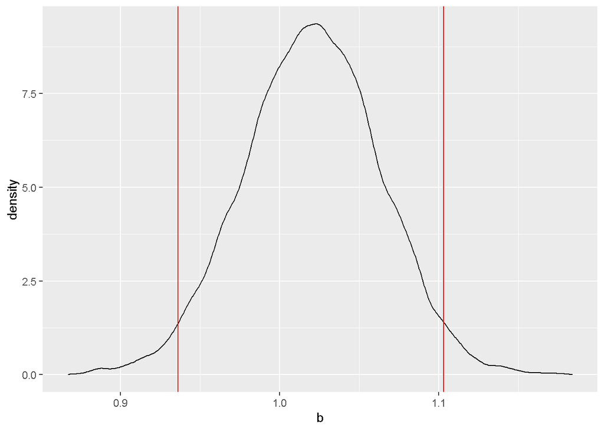

```r
# Plot the values for b and mark the credible interval
ggplot(weight_chains_long, aes(x = b)) +
    geom_density() +
    geom_vline(xintercept = ci_b_95, color = "red")
```

## Calculating Posterior Predictions

Now let us consider that we want to predict weight of a specific individual who is 180 cm tall.

```r
# Calculate m for 180 cm tall individuals.
weight_chains_long <- weight_chains_long %>%
    mutate(m_180 = a + b * 180)

# Simulate and store a prediction for each set of parameters
weight_chains_long <- weight_chains_long %>%
    mutate(Y_180 = rnorm(n=100000, mean = m_180, sd = s))

# View the head of the dataframe
head(weight_chains_long)
```

```
##           a        b        s iter    m_180    Y_180
## 1 -112.9908 1.063346 9.730646    1 78.41139 84.90114
## 2 -113.7648 1.068119 9.631675    2 78.49658 69.74110
## 3 -113.8473 1.067175 9.657773    3 78.24432 57.21178
## 4 -113.6368 1.069310 9.636325    4 78.83904 69.79068
## 5 -114.4460 1.074970 9.204933    5 79.04861 59.76722
## 6 -114.4554 1.074614 9.362281    6 78.97514 92.27337
```

```r
# Calculate the 95% credible interval for our prediction
ci_180_95 <- quantile(weight_chains_long$Y_180, probs = c(0.025, 0.975))
ci_180_95
```

```
##     2.5%    97.5%
## 59.82890 96.55014
```

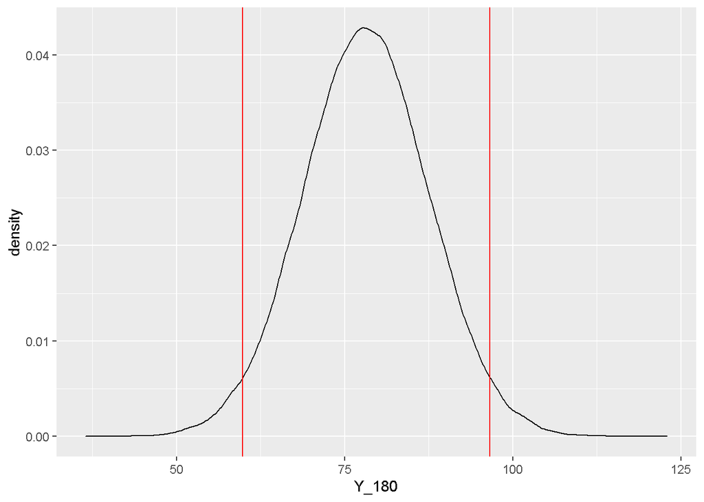

```r
# Plot the posterior predictions and mark the credible interval
ggplot(weight_chains_long, aes(x = Y_180)) +
    geom_density() +
    geom_vline(xintercept = ci_180_95, color = "red")
```

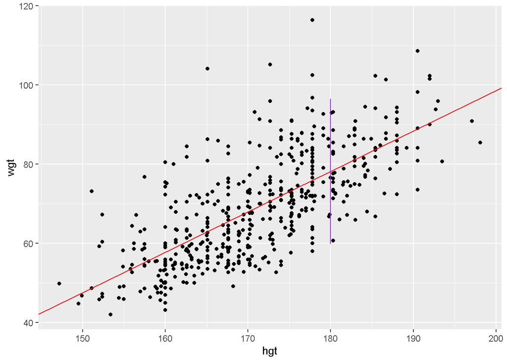

```r
# Visualize the credible interval on our scatterplot of bdims data
ggplot(bdims, aes(x = hgt, y = wgt)) +
    geom_point() +
    geom_abline(intercept = mean(weight_chains_long$a), slope = mean(weight_chains_long$b), color = "red") +
    geom_segment(x = 180, xend = 180, y = ci_180_95[[1]], yend = ci_180_95[[2]], color = "purple")
```

## Summary

We used RJAGS to perform some simple MCMC simulations. We reviewed the output of these simulations, created several visualizations, investigated point estimates, and calculated credible intervals.